# Trabajo Final

Trabajo Final Fernanda Villanueva 15/11/2021

## **Introducción**

El Índice de Desarrollo Humano es un indicador (IDH) elaborado por el Programa de las Naciones Unidas para el Desarrollo. Fue creado para enfatizar que el criterio último para medir el desarrollo de un país deben ser las personas y el desarrollo de sus capacidades y no el crecimiento económico por sí solo. De esta manera, el IDH es una medida que resume los logros clave de los países en dimensiones clave para el desarrollo humano, tales como una esperanza de vida larga y saludable, tener una calidad de vida decente o aspectos como el acceso a educación, salud, entre otros.

Si bien el IDH está compuesto por múltiples dimensiones, el objetivo de este trabajo se centra específicamente en el análisis de la dimensión “Salud”, que es medida a partir de la esperanza de vida en años al nacer en 189 países del mundo. Así, se busca determinar, mediante un análisis de regresión, cómo difiere la esperanza de vida entre los distintos países según sus respectivas realidades. Para esto, se utilizarán otras variables como el porcentaje del PBI destinado a Salud, la tasa de mortalidad infantil (cada 1000 infantes) y la tasa de homcidios (cada 100 mil habitantes) con el propósito de complementar el análisis y corroborar si aspectos como la violencia o el gasto público influyen en la esperanza de vida al nacer medida en años. Asimismo, posteriormente, se añadirán otras variables que miden el índice de inequidad de género a fin de realizar un análisis de cluster y un análisis factorial.

## **Explicación de variables**

#### **a) Variable dependiente**

**- Esperanza de vida al nacer medida en años (EVA)**

Como se explica en el paper titulado “The relationship between life expectancy at birth and health expenditures estimated by a cross-country and time-series analysis”, el resultado de los sistemas de salud se expresan mediante indicadores de longevidad como la esperanza de vida (al nacer, a partir de los 65 años o de vida saludable), dado que este es un buen *proxie* para medir el estado de salud de toda una población, pues, mientras mayor sea la esperanza de vida, más sana será su población. Asimismo, la cantidad de años de esperanza de vida en cada población es impactada por otras variables como, por ejemplo, el gasto sanitario de cada país (Jaba et al., 2014). En ese sentido, la elección de la variable EVA como dependiente responde a que la cantidad de años de esperanza de vida al nacer que tenga cada población se verá impactada (en menor o mayor medida) por la existencia de múltiples variables como el porcentaje de gasto del PBI que destina cada país a salud, la mortandad infantil o la tasa de homicidios.

#### **b) Variables independientes**

**- Porcentaje del PBI destinado a la salud (GPBI)**

También según el paper previamente mencionado, múltiples estudios, principalmente en países desarrollados, han demostrado que el gasto sanitario, entendido como el porcentaje del PBI que se dedica a la Salud, tiene un impacto positivo en la esperanza de vida en años de cada país. Este paper concluyó que existe una relación entre las variables esperanza de vida y gasto sanitario per cápita, es decir, mientras se gastaba en salud, mayor era el aumento de años de longevidad. Un ejemplo claro de esto son los países europeos, los cuales cuentan con la mayor esperanza de vida y también son los que más gastan en salud (Jaba et al., 2014). Por esto, se consideró que el GPBI es una variable determinante para explicar nuestra variable dependiente (EVA).

**- Tasa de mortalidad infantil por cada 1 000 infantes (TMI)**

Según el paper titulado “Imbalance in Life Table: Effect of Infant Mortality on Lower Life Expectancy at Birth”, la elevada mortalidad infantil y de la primera infancia (hasta los 5 años) derivan en valores más bajos de la esperanza de vida al nacer que en otras edades y esta tasa de mortalidad, a su vez, se ve afectada cuando se analiza respecto a otros factores como género, condición socioeconómica, entre otros. El estudio elaborado por el autor Fazle Rabbi demuestra cómo la tasa de mortalidad infantil afecta a la esperanza de vida al nacer y cómo esta varía de acuerdo a si se trata de países desarrollados o en vías de desarrollo (Fazle Rabbi, 2013). En ese sentido, se consideró a la variable TMI como otra variable independiente que explica a EVA.

**- Tasa de homicidios por cada 100 000 habitantes (HR)**

## **1. Análisis de Regresión**

- EVA: esperanza de vida en años al nacer
- GPBI: porcentaje del PBI destinado a salud
- TMI: tasa de mortalidad infantil (cada 1000 infantes)
- HR: tasa de homicidios (cada 100 000 habitantes)

#### **Caso de Estudio**

La base de datos fue recogida del repositorio de data de la Organización de las Naciones Unidas respecto al Índice de Desarrollo Humano. Nuestro caso de estudio analiza cómo la esperanza de vida en años al nacer en 189 países del mundo puede ser alterada por otros factores tales como el gasto saniario (% del PBI), la tasa de mortalidad infantil y la tasa de homicidios. Nuestra hipótesis planteada es que la esperanza de vida en años (EVA) depende y será diferente en cada país de acuerdo a las variables GPBI, TMI y HR.

Para comprobar nuestra hipótesis, realizaremos una tabla de regresión que incluye a todas las variables explicativas (HR, TMI, GPBI). Cabe resaltar que la elección de este modelo de regresión corresponde a un análisis previo de comparación de modelos con la prueba Anova que demostraba que este era el más adecuado.

**Tabla de Regresión**

```
##
## ===============================================
##                         Dependent variable:
##                     ---------------------------
##                                 EVN
## -----------------------------------------------
## Constant                     78.358***
##                               (0.749)
##
## HR                           -0.048**
##                               (0.021)
##
## TMI                          -0.340***
##                               (0.014)
##
## GPBI                         0.316***
##                               (0.090)
##
## -----------------------------------------------
## Observations                    138
## R2                             0.850
## Adjusted R2                    0.847
## Residual Std. Error      2.666 (df = 134)
## F Statistic          254.017*** (df = 3; 134)
## ===============================================
## Note:               *p<0.1; **p<0.05; ***p<0.01
```

Nuestra relación viene representada por la siguiente ecuación:

**EVN = 78.358 + -0.048xHR + -0.340xTMI + 0.316xGPBI + ϵ**

De esta tabla de regresión, podemos interpretar lo siguiente:

En primer lugar, la variable HR (tasa de homocidios por cada 100 mil habitantes) tiene un efecto significativo al 0.05 y también un efecto inverso de -0.048, lo que indica cuánto varía EVN, en este caso negativamente, cuando HR incrementa en una unidad. Esto quiere decir que, mientras la tasa de homocidios incremente, la cantidad de años de esperanza de vida al nacer disminuirá en 0.048. En segundo lugar, respecto a TMI (tasa de mortalidad infantil), controlada por HR, tiene un efecto significativo al 0.01 y la magnitud de su efecto negativo es -0.340, lo que significa que, mientras la tasa de mortalidad infantil incremente una unidad, menor será la esperanza de vida. En tercer lugar, la variable GPBI (% del PBI destinado a salud) sí tiene un efecto positivo y es de 0.316, es decir, mientras este aumente en una unidad, la esperanza de vida en años incrementará en 0.316. Finalmente, también es importante analizar el R cuadrado ajustado, ya que este es 0.847, cercano a 1, es decir, el escenario ideal para sostener que el modelo funciona.

## **2. Análisis de Conglomerados**

Para realizar el análisis de Cluster, añadiremos otra base de datos referente al índice de inequidad de género en los países del mundo.

```
## [[1]]
## [1] "paises" "EVN"    "GPBI"   "TMI"    "HR"
##
## [[2]]
## [1] "paises"                 "gender_inequality"      "education"
## [4] "life_expectancy_female"
```

#### **Método de partición (PAM)**

Previamente, a partir de un análisis del gráfico de la silueta, se determinó que el método de partición (PAM) era el más adecuado para clusterizar y dividir nuestros datos en grupos.

#### **Gráfica con escalamiento multidimensional**

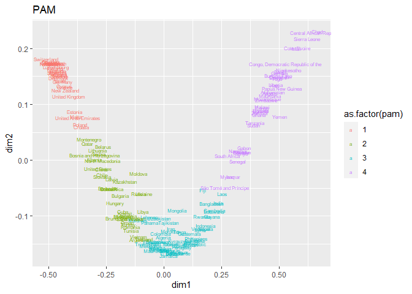

Como se observa, tenemos la gráfica en dos dimensiones final que ubica a los países en el mapa. Estos ya se encuentran clusterizados por el método de partición PAM.

A partir del gráfico, observamos cómo los países agrupados bajo el color naranja son los que presentan una cantidad mayor de años de esperanza de vida al nacer y menor índice de inequidad de género y están conformados por países desarrollados como Suiza, Alemania, Luxemburgo o Reino Unido. Por el otro extremo, los países agrupados en el color morado son los que presentan una cantidad menor de longevidad y un mayor índice de inequidad de género y está conformado principalmente por países de Medio Oriente y África. También los grupos de color verde se acercan relativamente un poco más a tener más longevidad y menor índice de inequidad, mientras que los de color celeste se acercan, aunque no tanto, al grupo con poca esperanza de vida en años y un índice alto de inequidad de género.

## **3. Análisis de Variables Latentes**

```
## Kaiser-Meyer-Olkin factor adequacy
## Call: psych::KMO(r = corMatrix)
## Overall MSA =  0.82
## MSA for each item =
##                    EVN                   GPBI                    TMI
##                   0.77                   0.74                   0.90
##                     HR      gender_inequality              education
##                   0.66                   0.88                   0.85
## life_expectancy_female
##                   0.76
```

Recordamos que el KMO va de 0 a 1, por lo que el 0.82 obtenido en nuestro caso indica que las variables están bastante relacionadas. Para esta data, todas las variables parecen ser adecuadas para explicar la variable latente que estamos creando. Además, en la data, se sugiere que se debe desprender un concepto/ variable latente.

**- Visualizamos**

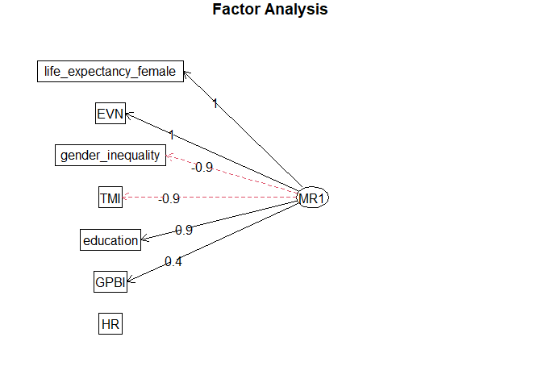

Como se observa, nuestro concepto latente MR1 está conformado por otras variables relacionadas a la esperanza de vida y la inequidad de género.

## **Conclusiones**

En primer lugar, el análisis de regresión corrobora la hipótesis de que la variable dependiente escogida para el caso de estudio, la esperanza de vida en años al nacer, es afectada por las variables independientes tasa de homicidios, tasa de mortalidad infantil y porcentaje del PBI destinado al gasto sanitario. Según la tabla de regresión elaborada, las primeras dos variables impactan negativamente a EVN, es decir, mientras que estas incrementen, la longevidad se reducirá en 0.048 y 0.340 respectivamente; al contrario, mientras el porcentaje de gasto sanitario incremente, la longevidad aumentará en 0.316. Asimismo, el R cuadrado del modelo es de 0.850, el cual se acerca al escenario ideal de 1, lo que implica que el modelo funciona. En segundo lugar, en el análisis de conglomerados, añadiendo las variables del índice de inequidad de género, se crearon 4 clusters por la estrategia de partición que muestran cómo los países agrupados bajo el color naranja son los que presentan una cantidad de años de esperanza de vida al nacer y menor índice de inequidad de género y están conformados por países desarrollados (principalmente europeos). Por el otro extremo, los países agrupados en el color morado son los que presentan una cantidad menor de longevidad y un mayor índice de inequidad de género y está conformado principalmente por países de Medio Oriente y África. También los grupos de color verde se acercan relativamente un poco más a tener más longevidad y menor índice de inequidad, mientras que los de color celeste se acercan, aunque no tanto, al grupo con poca esperanza de vida en años y un índice alto de inequidad de género. En tercer y último lugar, en el análisis factorial, se creó una variable latente a partir de las variables correspondientes a EVN (EVN, GBPI, TMI, HR) y al índice gender_inequality (gender_inequality, life_Expectancy_female, education).

## **1. Análisis de Regresión**

La primera hipótesis: el número de años de esperanza de vida al nacer en 189 países del mundo responde al porcentaje del PBI destinado al gasto sanitario, controlado por la variable tasa de homicidios (cada 100 mil habitantes)

```r
modelo1=formula(EVN~HR+GPBI)

library(stargazer)
reg1=lm(modelo1,data=data)
stargazer(reg1,type = "text", intercept.bottom = FALSE)
```

```
##
## ===============================================
##                         Dependent variable:
##                     ---------------------------
##                                 EVN
## -----------------------------------------------
## Constant                     70.041***
##                               (1.546)
##
## HR                           -0.164***
##                               (0.049)
##
## GPBI                         0.835***
##                               (0.203)
##
## -----------------------------------------------
## Observations                    138
## R2                             0.190
## Adjusted R2                    0.178
## Residual Std. Error      6.181 (df = 135)
## F Statistic           15.814*** (df = 2; 135)
## ===============================================
## Note:               *p<0.1; **p<0.05; ***p<0.01
```

Cuando probamos esta primera hipótesis, observamos que GPBI tiene un efecto significativo al 0.01. Además, que el efecto es directo, dado que el coeficiente es positivo; así, su efecto es de 0.835, lo que indica cuánto varía la esperanza de vida en años cuando GPBI (% del PBI destinado a gasto saniario) incrementa en una unidad, controlado por HR. El R cuadrado es 0.178, un nivel bajo.

La ecuación que representa esta relación es la siguiente:

```
 EVN = 70.041 + -0.164xHR + 0.835xGPBI + ϵ
```

Ahora, veremos el efecto de la magnitud de la tasa de mortalidad infantil (TMI) y con la variable porcentaje del PBI destinado a gasto sanitario (GPBI)

```r
modelo2=formula(EVN~HR+TMI+GPBI)

reg2=lm(modelo2,data=data)
stargazer(reg2,type = "text", intercept.bottom = FALSE)
```

```
##
## ===============================================
##                         Dependent variable:
##                     ---------------------------
##                                 EVN
## -----------------------------------------------
## Constant                     78.358***
##                               (0.749)
##
## HR                           -0.048**
##                               (0.021)
##
## TMI                          -0.340***
##                               (0.014)
##
## GPBI                         0.316***
##                               (0.090)
##
## -----------------------------------------------
## Observations                    138
## R2                             0.850
## Adjusted R2                    0.847
## Residual Std. Error      2.666 (df = 134)
## F Statistic          254.017*** (df = 3; 134)
## ===============================================
## Note:               *p<0.1; **p<0.05; ***p<0.01
```

```
EVN = 78.358 +  -0.048xHR + -0.340xTMI + 0.316xGPBI + ϵ
```

Ahora, aplicamos la prueba anova para comparar ambos modelos y observar si difieren entre sí.

```r
tanova <- anova(reg1,reg2)
stargazer(tanova,type = "text", summary = F, title = "Tabla de Análisis de Varianza")
```

```
##
## Tabla de Análisis de Varianza
## ===============================================
##   Res.Df    RSS    Df Sum of Sq    F    Pr(> F)
## -----------------------------------------------
## 1  135   5,158.049
## 2  134    952.071  1  4,205.978 591.973    0
## -----------------------------------------------
```

Según la tabla de análisis de varianza, el modelo 2 reduce el error significativamente, por lo que esto justifica el uso del segundo modelo sobre el primero.

**Diagnósticos de la Regresión**

Para verificar que el modelo de regresión es el adecuado, es necesario verificar algunos requisitos.

**- Linealidad**

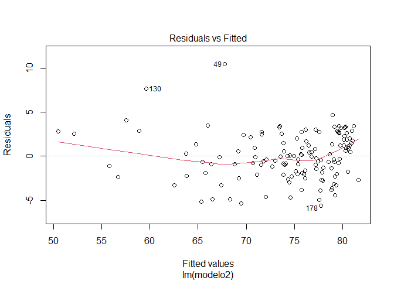

```r
plot(reg2, 1)
```

Según la linea roja, aparentemente la relación no es lineal, sin embargo, se observa que sí llega a tocar el cero para algunos valores del Y.

**- Homocedasticidad**

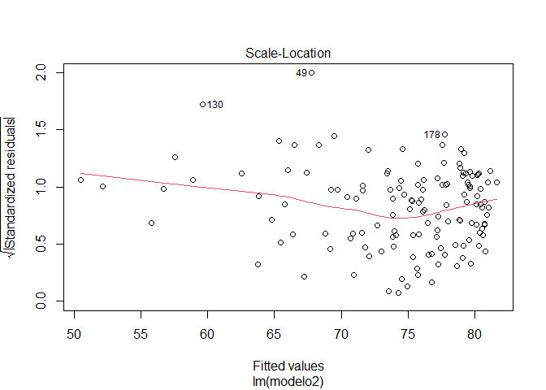

```r
plot(reg2, 3)
```

Si bien la tendencia de la linea roja no es del todo horizontal, el error en los valores parece ser medianamente estable.

Usamos el test de Breusch-Pagan

```r
library(lmtest)
bptest(reg2)
```

```
##
##  studentized Breusch-Pagan test
##
## data:  reg2
## BP = 5.62, df = 3, p-value = 0.1316
```

El p-value es 0.1316, se determina que este muestra homocedasticidad, por lo que el modelo es más fiable.

**- Normalidad de los residuos**

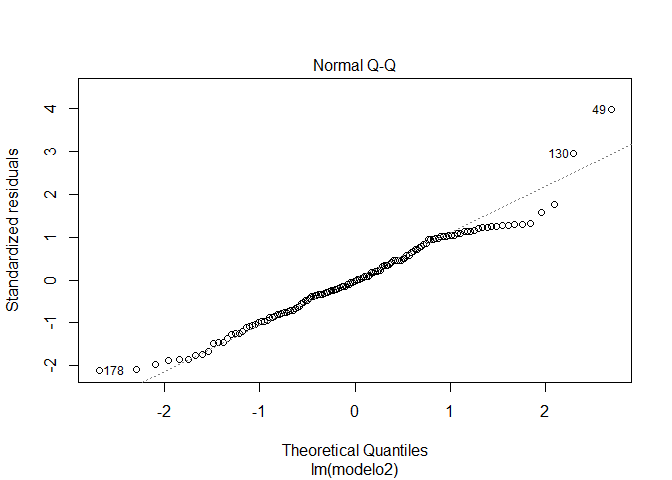

```r
plot(reg2, 2)
```

Le aplicamos el test de Shapiro a los residuos

```r
shapiro.test(reg2$residuals)
```

```
##
##  Shapiro-Wilk normality test
##
## data:  reg2$residuals
## W = 0.97317, p-value = 0.00801
```

Como el p-value es menor a 0.05, rechazamos la hipótesis nula y conlcuimos que los residuos no se distribuyen normalmente.

**- No multicolinealidad**

```r
library(DescTools)
VIF(reg2)
```

```
##       HR      TMI     GPBI
## 1.063248 1.124269 1.070872
```

Como los valores son menores a 5, concluimos que nuestras variables son diferentes entre sí.

**- Valores influyentes**

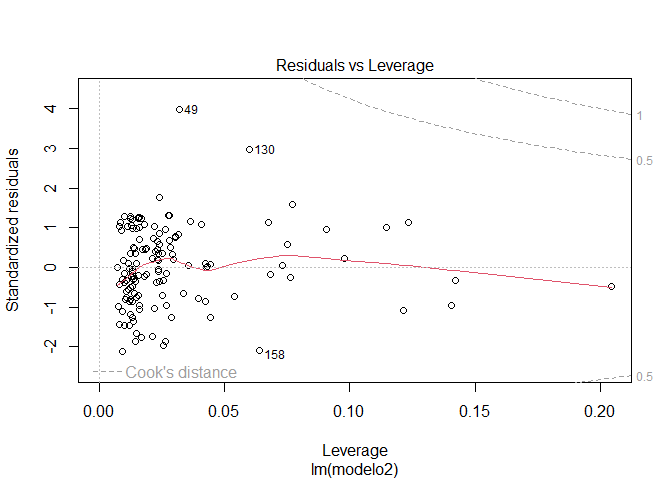

```r
plot(reg2, 5)
```

Recuperamos los casos influyentes

```r
checkReg2=as.data.frame(influence.measures(reg2)$is.inf)
head(checkReg2)
```

```
##   dfb.1_ dfb.HR dfb.TMI dfb.GPBI dffit cov.r cook.d   hat
## 1  FALSE  FALSE   FALSE    FALSE FALSE  TRUE  FALSE FALSE
## 3  FALSE  FALSE   FALSE    FALSE FALSE FALSE  FALSE FALSE
## 4  FALSE  FALSE   FALSE    FALSE FALSE FALSE  FALSE FALSE
## 7  FALSE  FALSE   FALSE    FALSE FALSE FALSE  FALSE FALSE
## 8  FALSE  FALSE   FALSE    FALSE FALSE FALSE  FALSE FALSE
## 9  FALSE  FALSE   FALSE    FALSE FALSE FALSE  FALSE FALSE
```

Ahora verificamos el indice de Cook y a los valores predecidos (los hat values):

```r
checkReg2[checkReg2$cook.d & checkReg2$hat,]
```

```
## [1] dfb.1_   dfb.HR   dfb.TMI  dfb.GPBI dffit    cov.r    cook.d   hat
## <0 rows> (or 0-length row.names)
```

No se observa ningún país que esté afectando significativamente a la regresión.

## **2. Análisis de Conglomerados**

Para el análisis de conglomerados, le añadiremos a nuestra base, que analiza la esperanza de vida, la base de datos de mi compañero Leonardo referida a la inequidad de género en los países del mundo.

```
## [[1]]
## [1] "paises" "EVN"    "GPBI"   "TMI"    "HR"
##
## [[2]]
## [1] "paises"                 "gender_inequality"      "gdp"
## [4] "education"              "life_expectancy_female"
```

```
## 'data.frame':    188 obs. of  3 variables:
##  $ paises           : chr  "Afghanistan" "Albania" "Algeria" "Andorra" ...
##  $ life_expectancy  : num  64.8 78.6 76.9 81.9 61.1 77 76.7 75.1 83.4 81.5 ...
##  $ gender_inequality: num  0.655 0.181 0.429 NA 0.536 NA 0.328 0.245 0.097 0.069 ...
```

```
##     paises          life_expectancy gender_inequality
##  Length:188         Min.   :53.30   Min.   :0.0250
##  Class :character   1st Qu.:67.38   1st Qu.:0.1810
##  Mode  :character   Median :73.95   Median :0.3690
##                     Mean   :72.68   Mean   :0.3454
##                     3rd Qu.:77.90   3rd Qu.:0.4820
##                     Max.   :84.90   Max.   :0.7950
##                                     NA's   :27
```

- Verficamos la distribución de los datos

Como se observa en el boxplot, los valores entre ambas variables son muy distintos, por lo que es necesario tranformar los datos para que el algoritmo de conglomeración no se confunda.

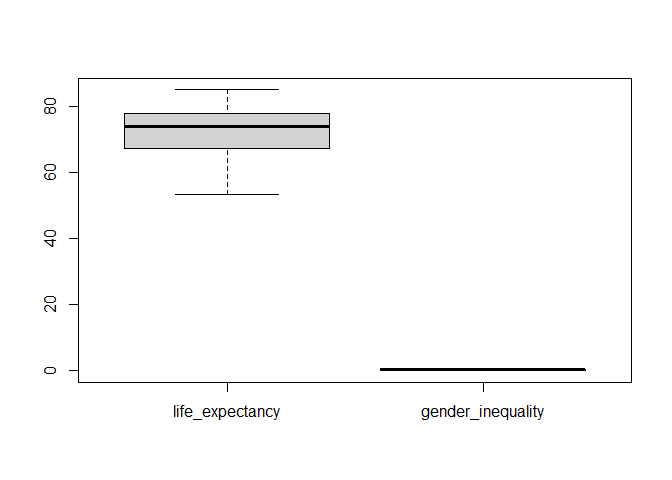

```r
boxplot(allData[,-1])
```

```r
library(BBmisc)
```

Primero, probamos colocando los valores en un rango de 0 a 1.

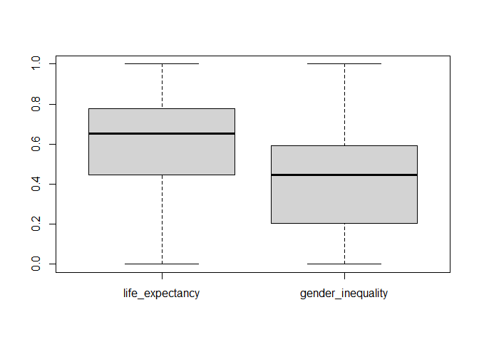

```r
boxplot(normalize(allData[,-1],method='range',range=c(0,1)))
```

Luego, probamos con estandarizarlos.

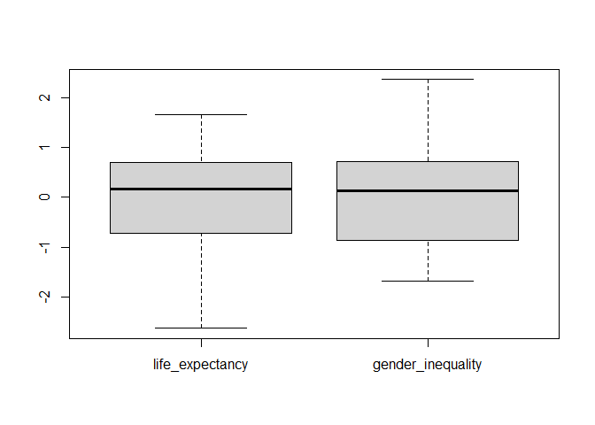

```r
boxplot(normalize(allData[,-1],method='standardize'))
```

Dado que las medias lucen más cercanas, decidimos quedarnos con la opción de **estandarización** de los datos.

```r
allData[,-1]=normalize(allData[,-1],method='standardize')
allData=allData[complete.cases(allData),]
summary(allData)
```

```
##     paises          life_expectancy    gender_inequality
##  Length:161         Min.   :-2.62198   Min.   :-1.6793
##  Class :character   1st Qu.:-0.64635   1st Qu.:-0.8618
##  Mode  :character   Median : 0.24674   Median : 0.1234
##                     Mean   : 0.05973   Mean   : 0.0000
##                     3rd Qu.: 0.78800   3rd Qu.: 0.7156
##                     Max.   : 1.61344   Max.   : 2.3559
```

Observemos las correlaciones

```r
cor(allData[,-1])
```

```
##                   life_expectancy gender_inequality
## life_expectancy         1.0000000        -0.8606207
## gender_inequality      -0.8606207         1.0000000
```

Se observa la existencia de una correlación negativa y, como lo ideal es que estas sean positivas, realizaremos un cambio de monotonía alterando la data multiplicando a la variable life_expectancy por -1.

```r
allData$life_expectancy=-1*allData$life_expectancy

cor(allData[,-1]) #verificamos
```

```
##                   life_expectancy gender_inequality
## life_expectancy         1.0000000         0.8606207
## gender_inequality       0.8606207         1.0000000
```

```r
#Preparamos los datos para la clusterización
dataClus=allData[,-1]
row.names(dataClus)=allData$paises   #convertimos la variable paises en row.names
```

**Procesos de clusterización**

1. Calculamos la distancia entre los casos

```r
library(cluster)
g.dist = daisy(dataClus, metric="gower")
```

2. Definimos la cantidad de clusters a partir de las gráficas
- Para estrategia de partición (PAM)

```r
library(factoextra)
```

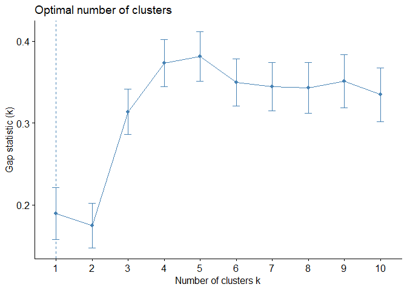

```r
fviz_nbclust(dataClus, pam,diss=g.dist,method = "gap_stat",k.max = 10,verbose = F)
```

En este caso, el mayor salto va de 2 a 3 y de 3 a 4.

- Para método jerárquico
1. Estrategia aglomerativa

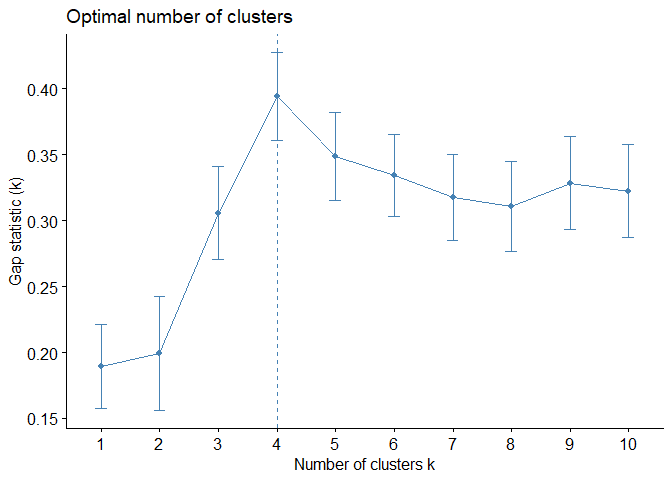

```r
fviz_nbclust(dataClus, hcut,diss=g.dist,method = "gap_stat",k.max = 10,verbose = F,hc_func = "agnes")
```

2. Estrategia de división

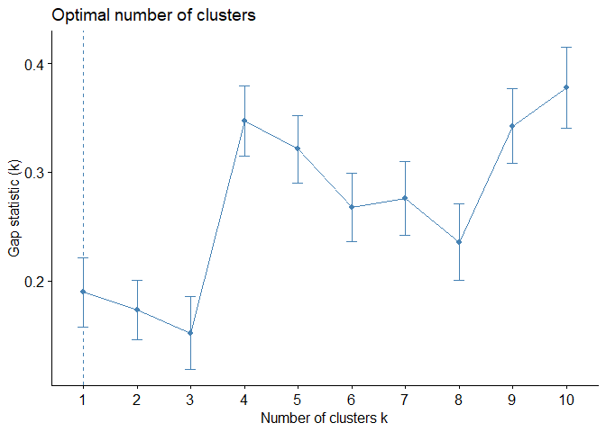

```r
fviz_nbclust(dataClus, hcut,diss=g.dist,method = "gap_stat",k.max = 10,verbose = F,hc_func = "diana")
```

En el caso de Diana, el número de cluster está entre 4 y 5.

Es a partir de este análisis que se decide dividir los datos en 4 grupos y esta será la cantidad que se usará para los distintos métodos.

#### Estrategia de Partición (PAM)

```r
set.seed(123)
pam.resultado=pam(g.dist,4,cluster.only = F)

# creamos una nueva columna llamada PAM

dataClus$pam=pam.resultado$cluster
aggregate(.~ pam, data=dataClus,mean)
```

```
##   pam life_expectancy gender_inequality
## 1   1       1.3255784         1.2285362
## 2   2      -0.5093251        -0.6164742
## 3   3      -0.0970928         0.3388031
## 4   4      -1.2552706        -1.4012311
```

En este caso, ordenamos los grupos por la esperanza de vida en años.

```r
original=aggregate(.~ pam, data=dataClus,mean)
original[order(original$life_expectancy),]
```

```
##   pam life_expectancy gender_inequality
## 4   4      -1.2552706        -1.4012311
## 2   2      -0.5093251        -0.6164742
## 3   3      -0.0970928         0.3388031
## 1   1       1.3255784         1.2285362
```

Así, después de ordernarlo por la variable esperanza de vida en años, tenemos que los países que se ubican en el grupo 4 son los que tienen un número de años de esperanza de vida mayor.

```r
#Recodificamos los valores
dataClus$pam=dplyr::recode(dataClus$pam, `4` = 1, `2`=2,`3`=3,`1`=4)
```

#### **Estrategia Jerárquica**

**a) Estrategia aglomerativa (algoritmo agnes)**

```
##   agnes life_expectancy gender_inequality      pam
## 1     1      1.40638345         1.2957006 4.000000
## 2     2     -0.53651337        -0.6823311 1.902439
## 3     3     -0.02201469         0.3750664 3.089286
## 4     4     -1.32202293        -1.4169058 1.000000
```

```
##   agnes life_expectancy gender_inequality      pam
## 4     4     -1.32202293        -1.4169058 1.000000
## 2     2     -0.53651337        -0.6823311 1.902439
## 3     3     -0.02201469         0.3750664 3.089286
## 1     1      1.40638345         1.2957006 4.000000
```

- Visualizamos con el dendograma

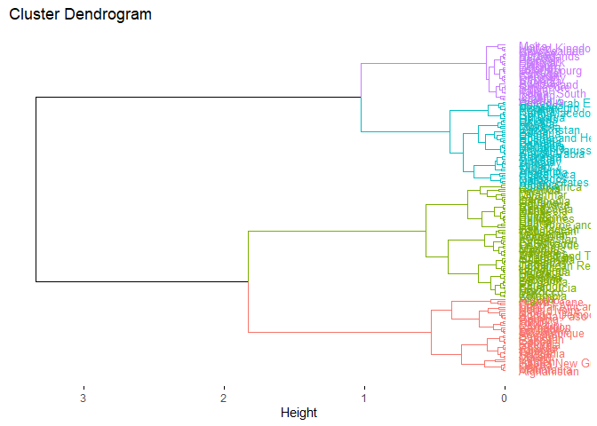

```r
fviz_dend(res.agnes, cex = 0.7, horiz = T)
```

Este gráfico nos ayuda a visualizar cómo se ha clusterizado los países con el método de aglomeración, es decir, en la que los países se van juntando para luego formar los clusters.

**b) Estrategia divisiva**

```
##   diana life_expectancy gender_inequality      pam    agnes
## 1     1       1.5093261        1.35190451 4.000000 4.000000
## 2     2      -1.0881620       -1.28043145 1.272727 1.363636
## 3     3      -0.3559404       -0.08591585 2.561404 2.561404
## 4     4       0.4055832        0.66645336 3.344828 3.172414
```

```
##   diana life_expectancy gender_inequality      pam    agnes
## 2     2      -1.0881620       -1.28043145 1.272727 1.363636
## 3     3      -0.3559404       -0.08591585 2.561404 2.561404
## 4     4       0.4055832        0.66645336 3.344828 3.172414
## 1     1       1.5093261        1.35190451 4.000000 4.000000
```

- Visualizamos con ayuda del dendograma

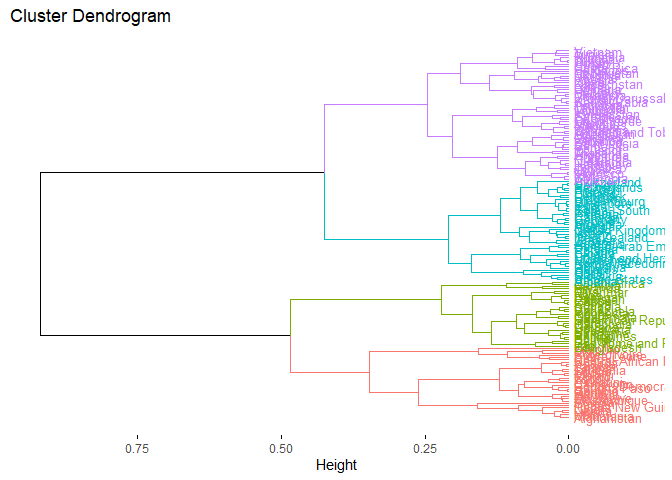

```r
fviz_dend(res.diana, cex = 0.7, horiz = T)
```

En este dendograma, observamos como los datos partieron de una unidad y fueron dividiéndose según su similitud.

- Comparamos ambas clasificaciones jerárquicas de aglomeración y división

```r
table(dataClus$diana,dataClus$agnes,dnn = c('division','aglomeracion'))
```

```
##         aglomeracion
## division  1  2  3  4
##        1 28 16  0  0
##        2  0 25 32  0
##        3  0  0 24  5
##        4  0  0  0 31
```

Esta es una estrategia de clausterización dura, lo que significa que sí o sí los paises deben formar parte de un cluster. Esto implica que al ordenarlo por la variable life_Expectancy exista una cantidad enorme de error como en este caso.

#### **Estrategia basada en densidad**

Para esta estrategia necesitamos usar el algoritmo **dbscan**, el cual requiere dos parámetros:

- La distancia *epsilon* para clusterizar los casos
- la cantidad mínima de puntos para formar el cluster. El valor de k es la cantidad de dimensiones.

Ahora, procedemos a usar **dbscan**:

Calculamos la distancia euclideana para luego calcular epsilon. Las posiciones serán la información para dbscan.

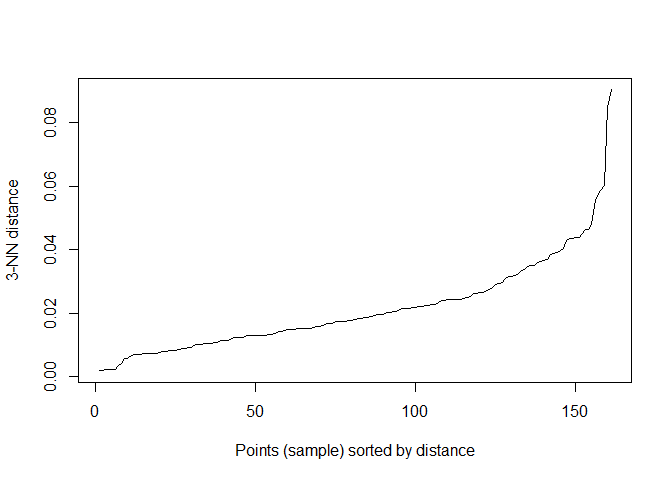

```r
g.dist.cmd = daisy(dataClus[,c('dim1','dim2')], metric = 'euclidean')

#Calculo de epsilon
library(dbscan)
kNNdistplot(g.dist.cmd, k=3)
```

Si se proyecta el codo, el epsilon está aproximadamente en 0.045.

- Obtenemos los clusters

```r
library(fpc)
db.cmd = fpc::dbscan(g.dist.cmd, eps=0.045, MinPts=2,method = 'dist') #en cuanto a la cantidad mínima de puntos colocamos 2, ya que tenemos dos variables
```

De esto, se puede saber:

```r
db.cmd
```

```
## dbscan Pts=161 MinPts=2 eps=0.045
##        0  1   2 3
## border 2  0   0 0
## seed   0 27 129 3
## total  2 27 129 3
```

Con la estrategia basada en densidad se han obtenido 3 clusters y hay 2 elementos que no pudieron ser clusterizados

**Evaluamos los resultados para decidir nuestro método**

Para este análisis, solo se puede realizar al caso de estrategia de partición, aglomeración y división. Verificaremos a cuál le fue mejor mediante el **cálculo de la silueta**

- Para PAM

```
##   cluster size ave.sil.width
## 1       1   41          0.51
## 2       2   37          0.38
## 3       3   51          0.42
## 4       4   32          0.70
```

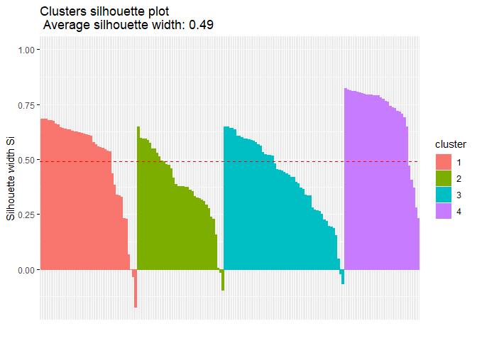

```r
fviz_silhouette(res.pam)
```

Como se observa en este gráfico, existen valores por debajo de la media que indican que su pertenencia a sus respectivos clusters no es necesariamente precisa, pero es mejor a que se ubique en otro. Tambien se observan valores negativos que quedaron fuera.

- Para AGNES

```
##   cluster size ave.sil.width
## 1       1   36          0.57
## 2       2   41          0.34
## 3       3   56          0.38
## 4       4   28          0.77
```

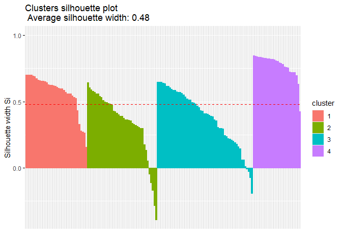

```r
fviz_silhouette(res.agnes)
```

- Para DIANA

```
##   cluster size ave.sil.width
## 1       1   31          0.46
## 2       2   44          0.60
## 3       3   57          0.34
## 4       4   29          0.43
```

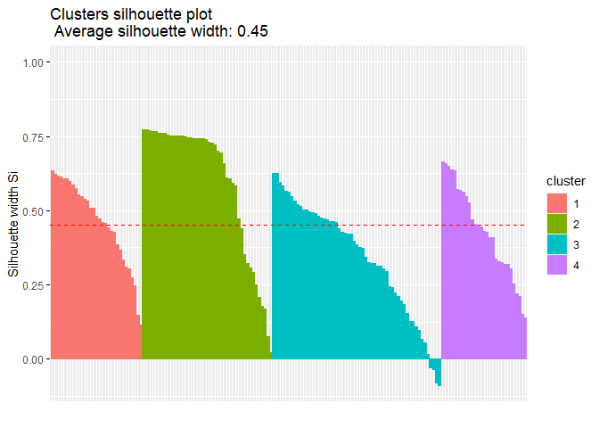

```r
fviz_silhouette(res.diana)
```

Todos los métodos presentan valores negativos, pero el mejor caso es el más cercano a 1, por lo que determinamos que nuestra estrategia de clusterización será PAM o partición.

**Graficamos**

Según nuestro análisis, sabemos que utilizaremos PAM (recordar que usamos life_Expectancy para ordenar)

```
##   pam life_expectancy gender_inequality    agnes    diana        dim1
## 4   4      -1.2552706        -1.4012311 3.750000 2.000000 -0.44884410
## 2   2      -0.5093251        -0.6164742 2.000000 2.675676 -0.19940080
## 3   3      -0.0970928         0.3388031 3.000000 3.372549  0.06459229
## 1   1       1.3255784         1.2285362 1.243902 1.731707  0.44991791
##         dim2
## 4  0.1448385
## 2 -0.0575829
## 3 -0.1313520
## 1  0.1023094
```

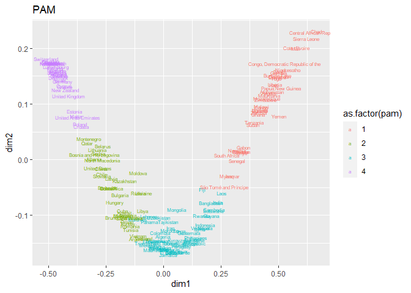

```r
proyeccion = cmdscale(g.dist, k=2,add = T) # k son dos dimensiones
dataClus$dim1 <- proyeccion$points[,1]
dataClus$dim2 <- proyeccion$points[,2]
base= ggplot(dataClus,aes(x=dim1, y=dim2,label=row.names(dataClus)))
base + geom_text(size=2, aes(color=as.factor(pam)))  + labs(title = "PAM")
```

Finalmente, tenemos la gráfica final en dos dimensiones que ubica a los países en el mapa. Estos ya se encuentran clusterizados por el método de partición PAM en 4 grupos.

Del gráfico, podemos identificar que países desarrollados como Nueva Zelanda, Reino Unido O Alemania son cercanos en tanto cuentan con una alta esperanza de vida en años y un bajo nivel de índice de desigualdad de género. También los que cuentan con menor esperanza de vida y un nivel más alto de inequidad de género son aquellos en vía de desarrollo.

## **3. Análisis de Variables Latentes**

**Proceso de Análisis Factorial Exploratorio**

- Realizaremos unas exploraciones previas, también quitaremos la variable paises para la exploración

```r
dontselect=c("paises")
select=setdiff(names(AVLdata),dontselect)
theDataP=AVLdata[,select] # sin los nombres del país

# esta es:
library(polycor)
corMatrix2=polycor::hetcor(theDataP)$correlations
```

- Exploramos las correlaciones

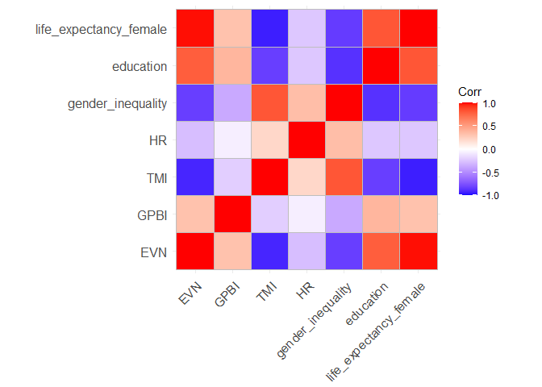

```r
library(ggcorrplot)
ggcorrplot(corMatrix2)
```

- Verificamos si los datos permiten factorizar

```r
library(psych)
psych::KMO(corMatrix2)
```

```
## Kaiser-Meyer-Olkin factor adequacy
## Call: psych::KMO(r = corMatrix2)
## Overall MSA =  0.82
## MSA for each item =
##                    EVN                   GPBI                    TMI
##                   0.77                   0.74                   0.90
##                     HR      gender_inequality              education
##                   0.66                   0.88                   0.85
## life_expectancy_female
##                   0.76
```

Recordamos que el KMO va de 0 a 1, por lo que el 0.82 obtenido en nuestro caso indica que las variables están relacionadas. Las variables TMI y gender_inequality parecen explicar más en la variable latente.

- Verificamos si la matriz de correlaciones es adecuada mediante dos pruebas
  1. Hipótesis nula: la matriz de correlación es una **matriz de identidad**

```r
cortest.bartlett(corMatrix2,n=nrow(theDataP))$p.value>0.05
```

```
## [1] FALSE
```

2. Hipótesis nula: la matriz de correlación es una **matriz singular**

```r
library(matrixcalc)

is.singular.matrix(corMatrix2)
```

```
## [1] FALSE
```

- Determinamos en cuantos factores o variables latentes podríamos encontrar en la data

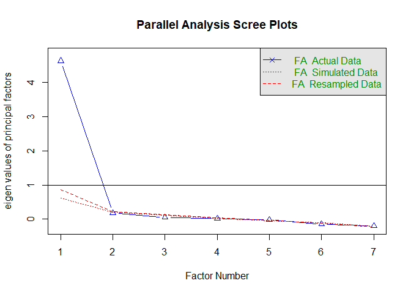

```
## Parallel analysis suggests that the number of factors =  1  and the number of components =  NA
```

```r
fa.parallel(theDataP,fm = 'ML', fa = 'fa',correct = T)
```

Parallel analysis suggests that the number of factors = 1 and the number of components = NA

Se sugiere 1, lo cual está bien porque indica que de las variables se puede desprender un concepto/variable latente.

- Redimensionamos a un número menor de factores

```r
library(GPArotation)
resfa2 <- fa(theDataP,
            nfactors = 1,
            cor = 'mixed',
            rotate = "varimax",
            fm="minres")
print(resfa2$loadings)
```

```
##
## Loadings:
##                        MR1
## EVN                     0.964
## GPBI                    0.370
## TMI                    -0.932
## HR                     -0.293
## gender_inequality      -0.932
## education               0.890
## life_expectancy_female  0.977
##
##                  MR1
## SS loadings    4.635
## Proportion Var 0.662
```

Observando la proporción de varianza, se tiene que todas las variables tienen un 66.2% en común entre sí. Considerando que este número es ligeramente mayor a 0.6, determinamos que está recogiendo información importante para el concepto latente.

Como ya se logro que cada variable esté con el factor, se obtiene una estructura simple.

- Visualizamos

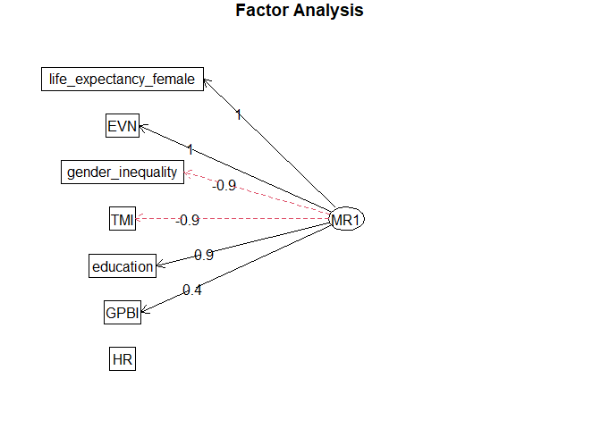

```r
fa.diagram(resfa2)
```

Evaluamos el resultado obtenido

- ¿Qué variables aportaron más a los factores?

```r
sort(resfa2$communality)
```

```
##                     HR                   GPBI              education
##             0.08593945             0.13705488             0.79140954
##                    TMI      gender_inequality                    EVN
##             0.86836201             0.86926375             0.92902593
## life_expectancy_female
##             0.95430880
```

En este caso, la variable que más aportaron fueron EVN, gender_inequality, TMI y life_expectancy_female

## **Análisis Factorial Confirmatorio**

El análisis de exploración anterior apoyaba la construcción de una variable latente a partir de la exploración de las variables y su relación. Ahora se puede proponer cómo construir los índices.

```r
model <- ' indice_EV  =~ EVN + HR + GPBI + TMI + education + gender_inequality + life_expectancy_female'
```

Ahora veamos qué dice el modelo

- Preparamos los tests

```r
allParamCFA=parameterEstimates(cfa_fit,standardized = T)
allFitCFA=as.list(fitMeasures(cfa_fit))
```

- observamos los resultados

Si cada indicador tiene buena relación con su latente dependerá del p-value

```r
allParamCFA[allParamCFA$op=="=~",]
```

```
##         lhs op                    rhs    est    se       z pvalue ci.lower
## 1 indice_EV =~                    EVN  0.988 0.052  19.046  0.000    0.887
## 2 indice_EV =~                     HR -0.299 0.090  -3.315  0.001   -0.476
## 3 indice_EV =~                   GPBI  0.335 0.072   4.683  0.000    0.195
## 4 indice_EV =~                    TMI -0.942 0.055 -17.229  0.000   -1.050
## 5 indice_EV =~              education  0.832 0.059  14.161  0.000    0.717
## 6 indice_EV =~      gender_inequality -0.880 0.060 -14.546  0.000   -0.998
## 7 indice_EV =~ life_expectancy_female  0.990 0.051  19.376  0.000    0.890
##   ci.upper std.lv std.all std.nox
## 1    1.090  0.988   0.991   0.991
## 2   -0.122 -0.299  -0.298  -0.298
## 3    0.475  0.335   0.336   0.336
## 4   -0.835 -0.942  -0.941  -0.941
## 5    0.947  0.832   0.834   0.834
## 6   -0.761 -0.880  -0.871  -0.871
## 7    1.090  0.990   1.000   1.000
```

- Comprobemos cómo salió el modelo

**El ChiSquare**

```r
allFitCFA[c("chisq", "df", "pvalue")] # pvalue>0.05
```

```
## $chisq
## [1] 130.3818
##
## $df
## [1] 14
##
## $pvalue
## [1] 0
```

En este caso, el p-value salió menor a 0.05.

**El índice de Tucker Lewi (debe ser mayor a 0.90)**

```r
allFitCFA$tli # > 0.90
```

```
## [1] 0.8986782
```

En este caso, es ligeramente menor a 0.90 lo cual no es positivo.

**La Raíz del error cuadrático (debe ser menor a 0.05)**

```r
allFitCFA[c('rmsea.ci.lower','rmsea' ,'rmsea.ci.upper')]
```

```
## $rmsea.ci.lower
## [1] 0.1781196
##
## $rmsea
## [1] 0.2102808
##
## $rmsea.ci.upper
## [1] 0.2440246
```

En este caso, es mayor a 0.05, por lo que tampoco cumple este requisito, lo que indica que no se podría construir un marco teórico con la variable latente creada a partir de las variables propuestas.

## **Bibliografía**

- Jaba, E., Balan, C. B., & Robu, I. B. (2014). The Relationship between Life Expectancy at Birth and Health Expenditures Estimated by a Cross-country and Time-series Analysis. Procedia Economics and Finance, 15, 108–114. https://doi.org/10.1016/s2212-5671(14)00454-7
- Fazle Rabbi, A. M. (2013). Imbalance in Life Table: Effect of Infant Mortality on Lower Life Expectancy at Birth. Journal of Scientific Research, 5(3), 479–488. https://doi.org/10.3329/jsr.v5i3.14105
- Canudas-Romo, V., & Aburto, J. M. (2019). Youth lost to homicides: disparities in survival in Latin America and the Caribbean. BMJ Global Health, 4(2), e001275. https://doi.org/10.1136/bmjgh-2018-001275